# Reproducible Manuscripts in R

Boston College

Jason Geller, PH.D.(he/him)

2025-04-02

## What is reproduciblity?

| Analysis / Data | Same | Different |
| --- | --- | --- |
| Same Analysis | **Reproducible** | **Replicable** |
| Different Analysis | **Robust** | **Generalisable** |

- If I take the same analysis pipeline and apply it to the same dataset, I get the same results
  - This is reproducibility

## What is open science?

- Openly sharing your research
  - Open publications
  - Open experimental protocols
  - Open software
  - Open data

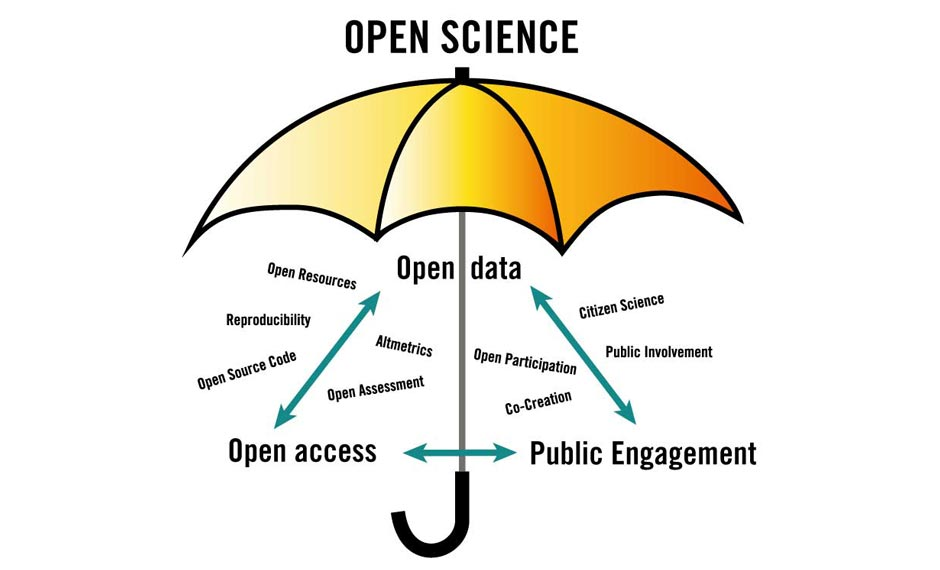

## Open Science + Reproducibility

- Today we are going to focus on reproducible manuscripts
  - Text
  - Code/analyses
  - Citations

## Packages

```r
library(palmerpenguins) # penguins
library(quarto) # qmd
library(rmarkdown) # markdown
library(tidyverse) # data wrangling
```

## Packages

```r
install.packages('tinytex') # for use with pdf
tinytex::install_tinytex()
# to uninstall TinyTeX, run tinytex::uninstall_tinytex()
```

- You should also have Zotero installed along with Better BibTeX (nice, but not necessary)

## Typical workflow

1. Do your analyses
2. Open a program (Word)
3. Copy-paste results and figures/tables
4. Manually format your results and citations

[video not shown]

# The Problem

## Word

[figure not shown]

[figure not shown]

## Inside

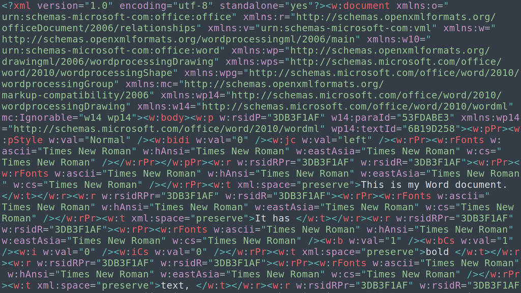

## Word issues

- A .docx file is a compressed folder with lots of files
  - Your text is buried in with a lot of formatting information
- Not reproducible
  - Code is divorced from writing
- Difficult to maintain
  - Errors!
- What do I share?
  - Lack of transparency

## What do we want?

- Combine narrative with code
- Automatically generate figures and tables
- Automatically render results in text
- Format the content into a scientific paper (including citations!)
- Something that looks pretty!
- Rinse & repeat

## Hello Quarto!

- Authoring framework for data science, designed for reprodicibility
- Unify and extends the R Markdown ecosystem.
- **Develop** and **Switch** formats without hassle.

[figure not shown]

## Hello Quarto!

- Websites (https://www.drjasongeller.com)
- Blogs
- Books (https://jgeller112.github.io/dis_flu_modeling/)
- Want to guess how I created these slides?

## Big universe

- RMarkdown for EVERYONE

[figure not shown]

## What is a Quarto?

[figure not shown]

## How Quarto Works

Quarto handles literate programming by using a series of programs:

- **`knitr`** executes all code chunks and creates a new markdown (`.md`) file
- **`pandoc`** takes the markdown file generated and converts it to the desired format.
- **Render** inside of RStudio handles the interaction.

## Advantages

**(1) Eliminate/reduce human error**

We found that half of all published psychology papers that use null-hypothesis significance testing (NHST) contained at least one p-value that was inconsistent with its test statistic and degrees of freedom. One in eight papers contained a grossly inconsistent p-value that may have affected the statistical conclusion)

[Nuijten et al., 2016](https://doi.org/10.3758/s13428-015-0664-2)

https://michelenuijten.shinyapps.io/statcheck-web/

## In the Wild: Data Science Gone Wrong

- [Retraction Watch](https://retractionwatch.com/)
- One such case of a paper being retracted due to an Excel error was the [Growth in a Time of Debt](https://www.nber.org/papers/w15639) by Reinhart & Rogoff (2010)
  - Found by graduate student Thomas Herndon and co-authors Michael Ash, and Robert Pollin.

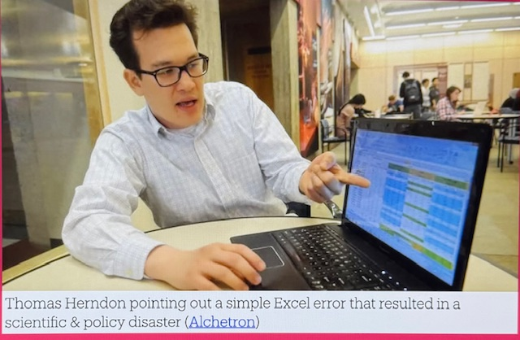

## Advantages

**(2) Easy revisions and specification of desired figures and tables**

*When revisions are requested, one might have to tweak tables and figures by hand constantly, leading to a major incentive never to rerun analyses because it would mean re-pasting and re-illustrating all the numbers and figures in a paper.*

## Advantages

**(3) Promote computational reproducibility**

- Easy verification and reproducilbility of research findings
- While programming environments may seem counter-intuitive for writing papers, they ultimately prevent mistakes and save time.

# Let’s Get Started!

## Getting started

**Note**

Always start a new project folder!

- Start from scratch
  - Creating a Quarto manuscript
    - RStudio: New Project > New Directory > Quarto Manuscript

# Overview of a Quarto Document

## Create a Quarto Document

In the top left, click the White Plus and select “Quarto Document…”

[figure not shown]

Creating a new Quarto Document

In the new prompt, enter a title, author name, and press “Create”

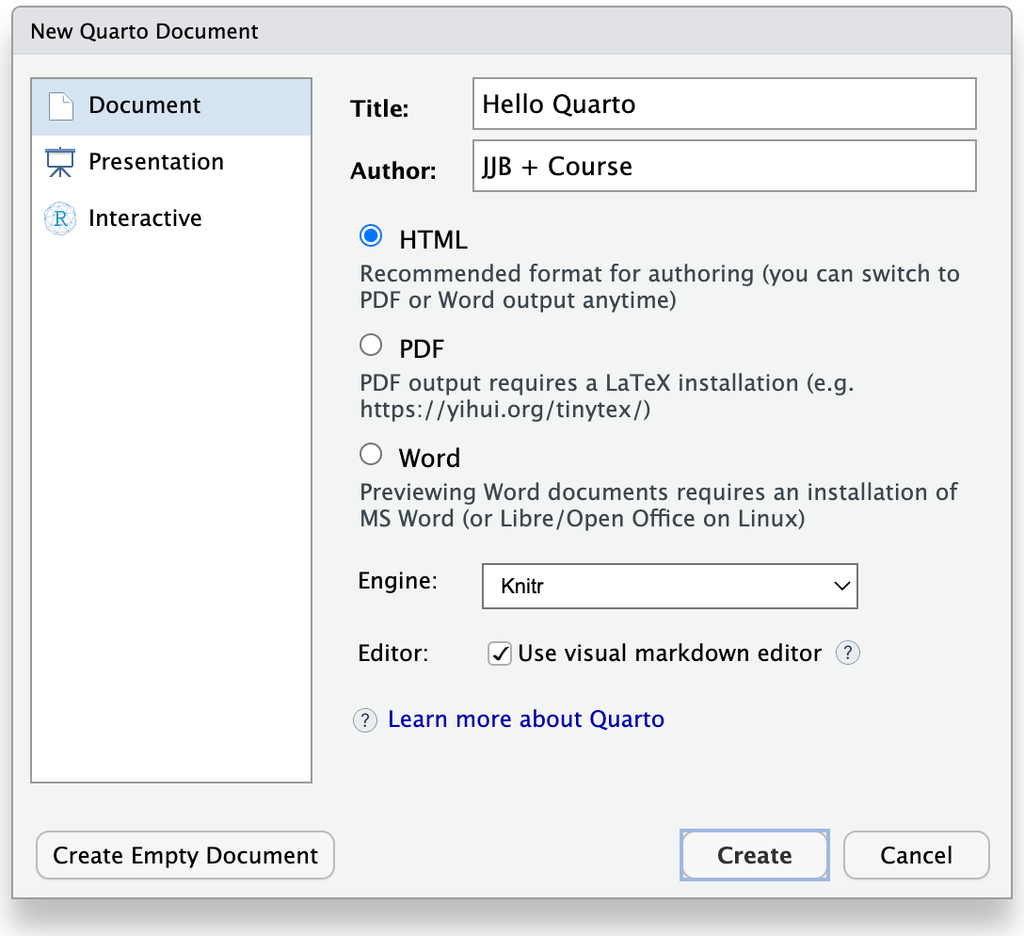

New Document Options

## Source vs. Visual Mode

[figure not shown]

Source Editing Mode

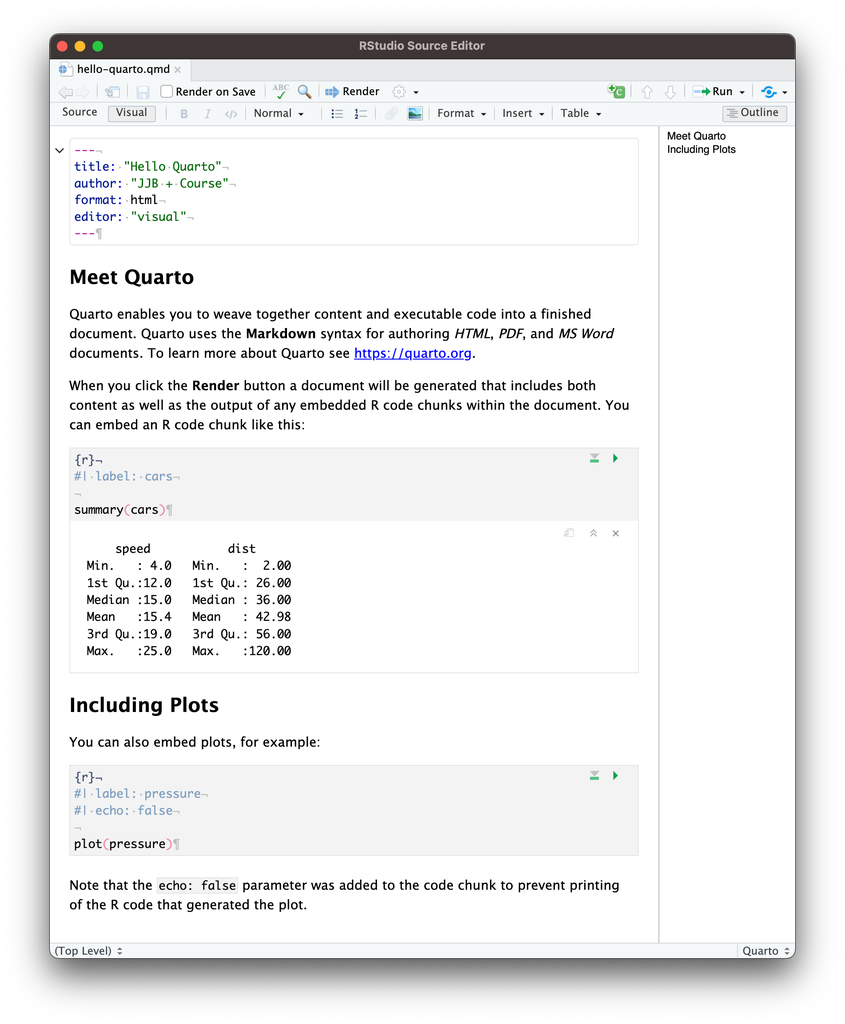

Visual Editing Mode

Visual Mode represents a **What You See Is What You Get (WYSIWYG) editor**. This mode is similar to Word.

## Getting started

- Go to the `Getting Started` section of website and complete each part

`05:00`

## Annotated Quarto Document

[figure not shown]

Annotated sections of the “Hello Quarto” document related to document information, text formatting, and code execution

## Output of a Quarto Document

[figure not shown]

Annotated source to output of the “Hello Quarto” document

## Navigating a Quarto Document

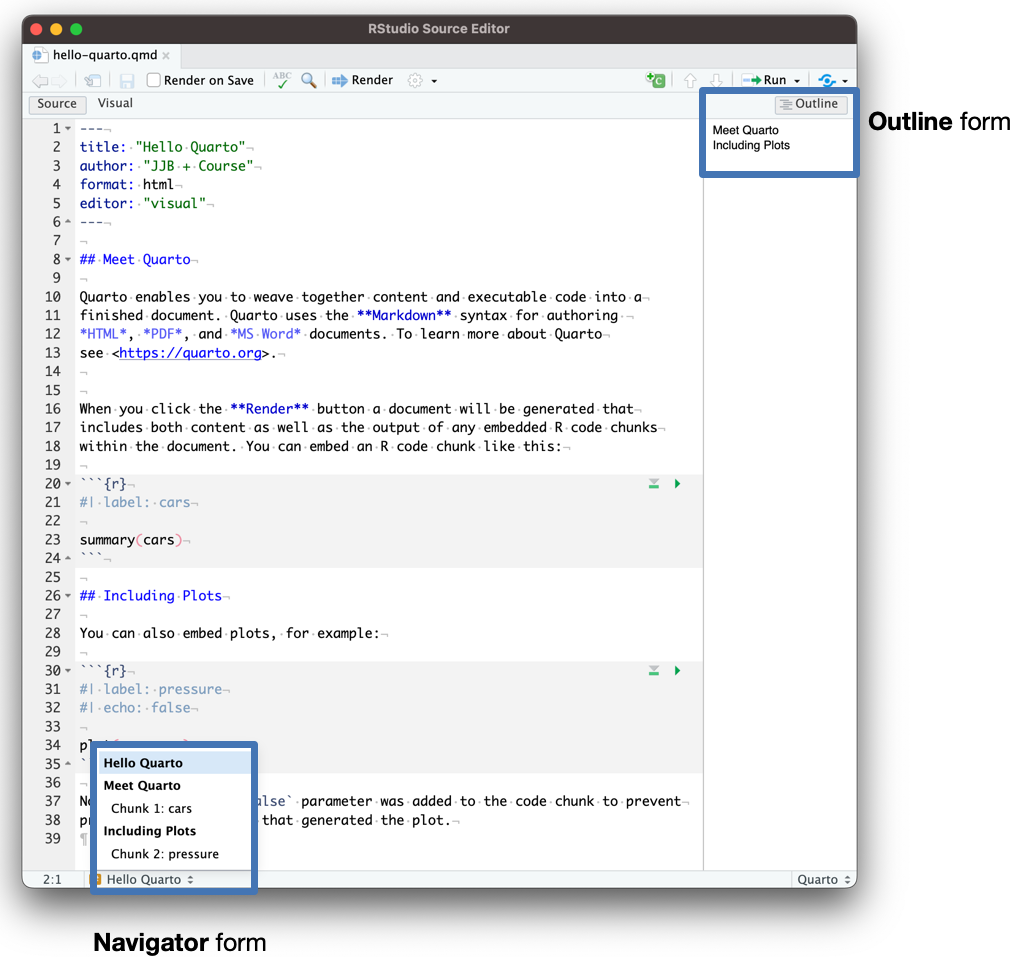

Annotated “Hello Quarto” document navigation options

## **Metadata & Header (YAML)**

- The YAML header contains basic metadata and rendering instructions

```yaml
---
title: My Reproducible Manuscript
authors:
  - name: Norah Jones
    affiliation: The University
    roles: writing
    corresponding: true
bibliography: references.bib
format: html
---
```

- Wait… what’s the YAML acronym?
  - Originally: “Yet Another Markup Language”
  - Later: “YAML Ain’t Markup Language”
- Set global manuscript options with key-value pairs

## **Code**

````markdown
```{r}
#| eval: true
1 + 1
```
````

```
[1] 2
```

## **Text**

```markdown
Section

This is a simple placeholder for the manuscript's main document [@knuth84].
```

# Writing in Markdown (NEXT)

BC 2025